# Wahrscheinlichkeitstheorie und Statistik

## Übung 4

### Allgemeine Informationen:

Bitte fügen Sie keine neuen Zellen hinzu oder löschen Zellen. Antworten gehören in die zugehörigen Zellen (unterhalb der Frage). Ist eine Funktion vorgegeben, darf weder der Name, noch die Anzahl oder Benennung der Argumente verändert werden!  
Unter den Antwortzellen gibt es oft noch eine leere Zelle, welche nicht editierbar ist. Diese Zellen sind Platzhalter für Tests die Sie ignorieren sollen.  
Beim Bearbeiten einer Übung kann es vorkommen, dass alte Variablenbelegungen noch im Arbeitspeicher vorliegen. Um sicher zu stellen, dass alles funktioniert sollte daher vor Abgabe der Kernel neugestartet werden und alle Zellen nacheinander ausgeführt werden (bswp via *Kernel -> Restart & Run All)*.

Code Zellen in die Sie Ihre Lösung schreiben sollen enthalten oft die Zeile ```raise NotImplementedError```. Dies vereinfacht uns die automatische Bewertung von Aufgaben. Wenn Sie die Zelle bearbeiten sollten Sie die Zeile auskommentieren oder löschen.

### Abgabe:

Geben Sie das Notebook einmal als *.ipynb Datei und einmal als **PDF** ab.

Herunterladen des Notebooks: Klicken Sie auf File > Download as > Notebook (.ipynb)

Herunterladen als PDF: Klicken Sie auf File > Download as > pdf (.pdf)

Laden Sie beide Dateien mit **unverändertem Namen** bei **LEA** hoch! Bitte geben Sie keine Archive (zip, rar, tar, etc) ab.

### Hausaufgaben Ansicht

Zur komfortablen Lösung der Hausaufgaben stellen wir Ihnen ein Addon für Jupyter Notebooks zur Verfügung. Dieses ist bereits installiert. Mit dem Addon werden Antwortzellen visuell hervorgehoben und es ist einfacher ersichtlich zu welcher Frage die Antwortzelle gehört.

Zum Aktivieren wählen Sie: View > Cell Toolbar > Assignment View

```python
mitglied1 = 'aali2s'
mitglied2 = 'ssaad12s'
```

## Verständnisfragen) [10 Punkte]

Nehmen Sie an Sie sind der oder die Vortragende für die Veranstaltung und möchten überprüfen wie gut die Studierenden den Vorlesungsinhalt verstanden haben.

Formulieren Sie hierfür **5** Fragen samt Antworten in den nächsten Zellen. Für jedes Frage-Antwort Paar gibt es 2 Punkte.

*Hinweis:* Die erste Zelle soll die Frage enthalten, die zweite die Antwort, die dritte wiederum die nächste Frage, die vierte die Antwort, ...

was ist eine Regressionsgerade?

Es misst den linearen Trend in den angegebenen Daten. Die Kovarianz ist ein wichtiger Teil der Regressionsgeraden, während der Korrelationskoeffizient angibt, wie sehr diese Trends in den beiden Datenreihen übereinstimmen.

Definieren Sie die Unabhängigkeit

Zwei diskete ZV sind unabhängig :⇔ für die gemeinsame Zähldichte von X und Y gilt : pX,Y(x, y) = pX(x) pY( y) ∀x,y

was ist der Nachteil des empirischen Kovarianz?

dass sigma^2 skalenabhängig ist, d.h., von der Größe der Stichprobenwerte x_1,.....,x_n bzw. y_1,.....,y_n abhängt.

Wie kann man “messen”, dass zwei ZVs NICHT unabhängig sind?

man zieht in Betracht: 1)bei Unabhängigkeit gilt: E[XY] = E[X]E[Y] 2)wir versuchen als Maß: E[XY] – E[X]E[Y] achtung!! nicht skalieren, da es von der Größe von E[X] und E[Y] abhängt 3)teile durch die Standardabweichung

Wofür braucht man Korrelationskoeffizient?

Korrelationskoeffizient braucht man um beziehung zwichen zwei Variablen zu messen, dass wie stark die beziehung existiert.

## Gewicht / Größe

Zusätzlich zu diesem Notebook wurde Ihnen die Datei `health.csv` zur Verfügung gestellt.

Dieser Datensatz enthält Umfrageergebnisse einer Gesundheitsumfrage unter Jugendlichen und jungen Erwachsenen aus den USA (https://www.icpsr.umich.edu/icpsrweb/DSDR/studies/21600).

Im Rahmen der National Longitudinal Study of Adolescent to Adult Health wurden 20000 Teilnehmer zu verschiedensten Themen rund um die Gesundheit befragt. Der Datensatz `health.csv` enthält einen Auszug der Fragen und Antworten von ca. 5000 Teilnehmern.

Der Datensatz enthält folgende Werte:

- AID - Pseudonym für jeden Teilnehmer
- H4WGT - Gewicht der Teilnehmer
- H4HGT - Größe der Teilnehmer
- BIO_SEX4 - Geschlecht der Teilnehmer
- H4OD1Y - Das Geburtsjahr der Teilnehmer

### Gewicht / Größe a) [5 Punkte]

Laden Sie die Daten in einen pandas *DataFrame* und benennen Sie die Spalten wie folgt um:

- H4WGT - Gewicht
- H4HGT - Groesse
- BIO_SEX4 - Geschlecht
- H4OD1Y - Geburtsjahr

Nennen Sie den neuen *DataFrame* `health`

```python
import pandas as pd

health = pd.read_csv('data/health.csv')
health = health.rename(columns={'H4WGT':'Gewicht' , 'H4HGT':'Groesse' , 'BIO_SEX4':'Geschlecht' , 'H4OD1Y':'Geburtsjahr'})
print(health.head(5))
#print(type(health))
#raise NotImplementedError()
```

```
        AID  Gewicht  Groesse Geschlecht  Geburtsjahr
0  57101310    113.9    180.0     Female         1976
1  57103869    107.8    202.0       Male         1976
2  57109625     68.0    161.0       Male         1981
3  57111071     89.4    177.0       Male         1981
4  57113943    150.6    185.5       Male         1979
```

```python
# Dies ist eine Testzelle, bitte ignorieren Sie diese!
```

### Gewicht / Größe b) [5 Punkte]

Plotten Sie Gewicht (x-Achse) und Größe (y-Achse) der Teilnehmer.

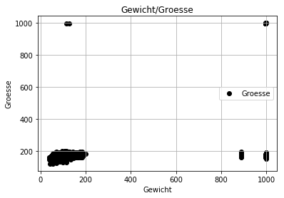

```python
# YOUR CODE HERE

import matplotlib.pyplot as plt

x = health.Gewicht
y = health.Groesse

plt.scatter(x,y, color='black')
plt.xlabel('Gewicht')
plt.ylabel('Groesse')
plt.grid()
plt.legend()
plt.title('Gewicht/Groesse')
plt.show()

#raise NotImplementedError()
```

### Gewicht / Größe c) [10 Punkte]

Anscheinend haben einige Teilnehmer Fantasieangaben zu Größe und Gewicht gemacht. Entfernen Sie alle Einträge die keinen Sinn ergeben (Gewicht > 250kg und Größe > 300cm). Speichern Sie Ihr Ergebnis wieder in der Variablen `health_cleaned`.

Plotten Sie das Ergebnis erneut.

```python
health_cleaned = health.loc[(health.Gewicht<250) & (health.Groesse<300)]
health_cleaned.head()
# YOUR CODE HERE
#raise NotImplementedError()
```

|  | AID | Gewicht | Groesse | Geschlecht | Geburtsjahr |
| --- | --- | --- | --- | --- | --- |
| 0 | 57101310 | 113.9 | 180.0 | Female | 1976 |
| 1 | 57103869 | 107.8 | 202.0 | Male | 1976 |
| 2 | 57109625 | 68.0 | 161.0 | Male | 1981 |
| 3 | 57111071 | 89.4 | 177.0 | Male | 1981 |
| 4 | 57113943 | 150.6 | 185.5 | Male | 1979 |

```python
# Dies ist eine Testzelle, bitte ignorieren Sie diese!
```

### Gewicht / Größe d) [10 Punkte]

Teilen Sie die Daten auf in Frauen und Männer. Plotten Sie für beide das Gewicht und die Größe in dem selben Plot mit verschiedenen Farben.

Speichern Sie die Daten für die Männer im DataFrame `men`.

Speichern Sie die Daten für die Frauen im DataFrame `women`.

```
Text(0.5,1,'Gewicht/Groesse')
```

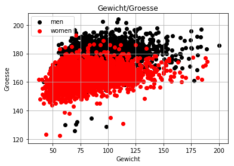

```python
men = health_cleaned.loc[health.Geschlecht=='Male']
women = health_cleaned.loc[health.Geschlecht=='Female']
#print(men.head())
#print(women.head())
plt.scatter((men.Gewicht),(men.Groesse), color='black',label='men')
plt.scatter((women.Gewicht),(women.Groesse), color='red', label='women')
plt.xlabel('Gewicht')
plt.ylabel('Groesse')
plt.grid()
plt.legend()
plt.title('Gewicht/Groesse')
# YOUR CODE HERE
#raise NotImplementedError()
```

```python
# Dies ist eine Testzelle, bitte ignorieren Sie diese!
```

### Gewicht / Größe e) [8 Punkte]

Erstellen Sie Histogramme für die Verteilung des Gewichts bei den Männern und Frauen, sowie für die Größe (4 Plots insgesamt)

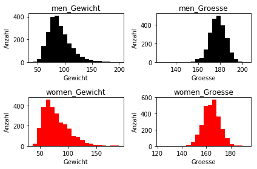

```python
# YOUR CODE HERE
fig, axs = plt.subplots(2, 2)

axs[0, 0].hist(men.Gewicht, bins = 20, color ='black')
axs[0,0].set_title('men_Gewicht')
axs[0,0].set_ylabel('Anzahl')
axs[0,0].set_xlabel('Gewicht')

axs[0,1].hist(men.Groesse, bins = 20, color ='black')
axs[0,1].set_title('men_Groesse')
axs[0,1].set_ylabel('Anzahl')
axs[0,1].set_xlabel('Groesse')

axs[1,0].hist(women.Gewicht, bins = 20, color ='red')
axs[1,0].set_title('women_Gewicht')
axs[1,0].set_ylabel('Anzahl')
axs[1,0].set_xlabel('Gewicht')

axs[1,1].hist(women.Groesse, bins = 20, color ='red')
axs[1,1].set_title('women_Groesse')
axs[1,1].set_ylabel('Anzahl')
axs[1,1].set_xlabel('Groesse')

plt.tight_layout()
plt.show()
#raise NotImplementedError()
```

### Gewicht / Größe f) [12 Punkte]

Erstellen Sie einen neuen Pandas *DataFrame* (analog zu untenstehender Tabelle) der die charakteristischen Werte der Verteilungen angibt. Nennen Sie Ihren *DateFrame* `verteilungen`.

| Merkmal | Geschlecht | Mittelwert | Median | Standardabweichung | Varianz |
| --- | --- | --- | --- | --- | --- |
| Gewicht | Male |  |  |  |  |
| Gewicht | Female |  |  |  |  |
| Gewicht | beide |  |  |  |  |
| Groesse | Male |  |  |  |  |
| Groesse | Female |  |  |  |  |
| Groesse | beide |  |  |  |  |

```python
import numpy as np

verteilungen = {
    'Merkmale':['Gewicht','Gewicht','Gewicht','Groesse','Groesse','Groesse'],
    'Geschlecht':['Male','Female','beide','Male','Female','beide'],
    'Mittelwert':[men.Gewicht.mean(), women.Gewicht.mean() , health_cleaned.Gewicht.mean()
                  ,men.Groesse.mean(), women.Groesse.mean() , health_cleaned.Groesse.mean() ],
    'Median':[men.Gewicht.median(), women.Gewicht.median() , health_cleaned.Gewicht.median()
                  ,men.Groesse.median(), women.Groesse.median() , health_cleaned.Groesse.median()],
    'Standardabweichung':[men.Gewicht.std(), women.Gewicht.std() , health_cleaned.Gewicht.std()
                  ,men.Groesse.std(), women.Groesse.std() , health_cleaned.Groesse.std()],
    'Varianz' : [men.Gewicht.var(), women.Gewicht.var() , health_cleaned.Gewicht.var()
                  ,men.Groesse.var(), women.Groesse.var() , health_cleaned.Groesse.var()]
}



#print(health_cleaned.Gewicht.mean())
#print(type(verteilungen))
verteilungen = pd.DataFrame(verteilungen)
print(verteilungen)

# YOUR CODE HERE
#raise NotImplementedError()
```

```
  Merkmale Geschlecht  Mittelwert  Median  Standardabweichung     Varianz
0  Gewicht       Male   91.311092    87.4           21.816752  475.970650
1  Gewicht     Female   78.868954    73.9           22.733735  516.822692
2  Gewicht      beide   84.586612    81.0           23.160469  536.407309
3  Groesse       Male  177.584592   178.0            7.702354   59.326252
4  Groesse     Female  163.943560   164.0            6.921287   47.904214
5  Groesse      beide  170.212158   170.0            9.968268   99.366365
```

```python
# Dies ist eine Testzelle, bitte ignorieren Sie diese!
```

### Gewicht / Größe g) [10 Punkte]

Beantworten Sie folgende Fragen:

1. Wieviel Prozent der Männer sind schwerer als der Durchschnitt der Männer?

   Speichern Sie Ihre Lösung in `maenner_schwerer_als_Durschnitt`
1. Wieviel Prozent der Frauen sind schwerer als der Durchschnitt der Frauen?

   Speichern Sie Ihre Lösung in `frauen_schwerer_als_Durschnitt`
1. Wieviel Prozent der Frauen sind schwerer als der durchschnittliche Mann?

   Speichern Sie Ihre Lösung in `frauen_schwerer_als_Durchschnittsmann`
1. Wieviel Prozent der Frauen sind größer als 50% der Männer?

   Speichern Sie Ihre Lösung in `frauen_groesser_als_Maenner`
1. Wieviel Prozent der Männer sind größer als 50% der Frauen?

   Speichern Sie Ihre Lösung in `maenner_groesser_als_Frauen`

*Hinweis:* Wenn die Lösung 30% lautet, speichern Sie den Wert als Fließkommazahl 0.3

```python
import random
maenner_schwerer_als_Durschnitt = ( ((men.loc[men.Gewicht>(verteilungen.Mittelwert[0])]).count()[0]) / (men.count()[0]) )
frauen_schwerer_als_Durschnitt = ( ((women.loc[women.Gewicht>(verteilungen.Mittelwert[1])]).count()[0]) / (women.count()[0]) )
frauen_schwerer_als_Durchschnittsmann = ( ((women.loc[women.Gewicht>(verteilungen.Mittelwert[0])]).count()[0]) / (men.count()[0]) )
frauen_groesser_als_Maenner = ((women["Groesse"].loc[women["Groesse"] >  men["Groesse"].median()]).count())/women["Groesse"].count()
#( ((women.loc[women.Groesse>(men['Groesse'].sample(round(int((men.count()/2)[0]))).mean())]).count()[0]) / (men.count()[0]) ) * 100
#maenner_groesser_als_Frauen = ( ((men.loc[men.Groesse>(women['Groesse'].sample(round(int((women.count()/2)[0]))).mean())]).count()[0]) / (women.count()[0]) ) * 100
#print(verteilungen.Mittelwert[0])
#tmp = max(men['Groesse'].sample(round(int((men.count()/2)[0]))))
#a = ( women.loc[women.Groesse> tmp ]  / men.count()[0] ) * 100
print(maenner_schwerer_als_Durschnitt)
```

```
0.4208027621924903
```

```python
# Dies ist eine Testzelle, bitte ignorieren Sie diese!
```

### Gewicht / Größe h) [15 Punkte]

Wir möchten versuchen das Gewicht einer Person in Abhängigkeit seiner Größe vorherzusagen. Dazu können wir eine Ausgleichsgerade durch die Punkte legen.

Eine Ausgleichsgerade ist eine Gerade die den mittleren quadratischen Abstand (das Quadrat der Residuen) zwischen der Gerade und den realen Datenpunkten minimiert.

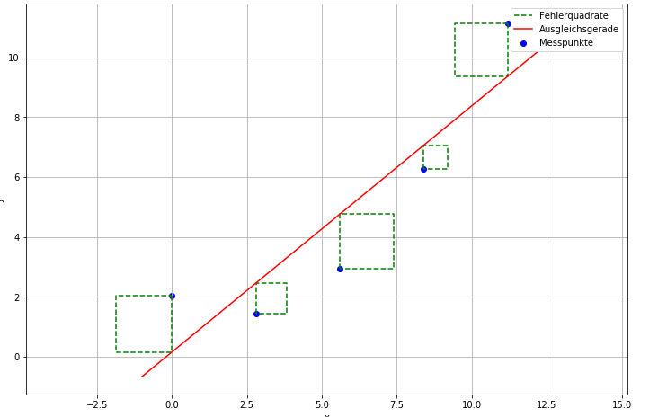

Implementieren Sie die Funktion `fitLine(x_observed, y_observed)` die für beobachtete X und Y Werte eine Ausgleichsgerade berechnet. Die Rückgabe der Funktion ist die Steigung und der Y-Achsenabschnitt der Geraden als Tupel.

*Hinweis:* Benutzen Sie keine bereits implementierten Funktionen für die Bestimmung der Ausgleichsgerade. Sie brauchen nur den Mittelwert (numpy.mean).

```python
def fitLine(x_observed, y_observed):
    '''
    Fits a line f(x) = m * x + b to the observations

    Arguments:
        x_observed -- x values of the data
        y_observed -- y values of the data
    Returns:
        m          -- slope
        b          -- intersect
    '''
    mytmp=np.cov(m=x_observed,y=y_observed)
    a = mytmp[0,1]/x_observed.var()
    b = y_observed.mean() - a*x_observed.mean()
    return a,b
    # YOUR CODE HERE
    #raise NotImplementedError()
```

```python
# Dies ist eine Testzelle, bitte ignorieren Sie diese!
```

### Gewicht / Größe i) [5 Punkte]

Berechnen Sie folgende Ausgleichsgeraden für die Frauen:

1. Vorhersage des Gewichts mittels der Größe
2. Vorhersage der Größe mittels des Gewichts

Speichern Sie Ihre Lösung in den Variablen `steigung1, achsenabschnitt1` sowie `steigung2, achsenabschnitt2`.

```python
# YOUR CODE HERE
fm , fb = fitLine(women.Gewicht,women.Groesse)
steigung1 = fm
achsenabschnitt1 = fb
tm , tb = fitLine(women.Groesse,women.Gewicht)
steigung2 = tm
achsenabschnitt2 = tb



print(steigung1)
print(steigung2)
print(achsenabschnitt1)
print(achsenabschnitt2)
#raise NotImplementedError()
```

```
0.07627166310714556
0.8228696979118547
157.9280933341302
-56.03523326138313
```

```python
# Dies ist eine Testzelle, bitte ignorieren Sie diese!
```

### Gewicht / Größe j) [10 Punkte]

Plotten Sie die Verteilung der Größe vs Gewicht für die Frauen und zeichnen die oben berechneten Geraden ein.

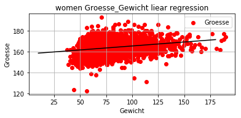

```python
import matplotlib.pyplot as plt


fig, ax = plt.subplots(ncols=1,nrows=1)
ax.grid(True)
ax.set_aspect('equal')
plt.scatter(women.Gewicht,women.Groesse , color='red')
plt.ylabel ('Groesse')
plt.xlabel ('Gewicht')
myline = lambda x: steigung1*x + achsenabschnitt1
myx = np.linspace(start=10., stop=180., num=50)
plt.plot(myx,myline(myx), color = 'black')
plt.title('women Groesse_Gewicht liear regression')
plt.legend()
plt.show()




# YOUR CODE HERE
#raise NotImplementedError()
```

### Gewicht / Größe k) [10 Punkte]

Implementieren Sie die Funktion `correlation(x, y)` welche den Korrelationskoeffizienten zwischen den Datenpunkten `x` und `y` berechnet.

*Hinweis:* Benutzen Sie keine vordefinierten Funktionen wie `scipy.stats.pearsonr` sondern implementieren Sie die Funktion selbst. Sie können selbstverständlich Funktionen wie `numpy.mean` oder `numpy.sqrt` benutzen.

Sollten Sie diese Teilaufgabe nicht lösen, können Sie im Folgenden mit der Funktion `scipy.stats.pearsonr` arbeiten.

```python
import numpy as np
def correlation(x, y):
    xdurchschnitt = x.mean()
    ydurchschnitt = y.mean()
    for_x = x-(x.mean())
    for_y = y-(y.mean())
    nenner = sum( (for_x*for_y) )
    for_x_sqr = sum(for_x**2)
    for_y_sqr = sum(for_y**2)
    zaehler = np.sqrt(for_x_sqr*for_y_sqr)
    erg = nenner/zaehler
    #erg =
    return erg
    # YOUR CODE HERE
    #raise NotImplementedError()
print(correlation(women.Gewicht,women.Groesse))
```

```
0.25052273425821475
```

```python
# Dies ist eine Testzelle, bitte ignorieren Sie diese!
```

### Gewicht / Größe l) [5 Punkte]

Berechnen Sie den Korrelationskoeffizienten für Größe und Gewicht der Frauen und speichern Sie Ihre Lösung in der Variablen `korrelation`.

Wieviel Prozent der Varianz der Daten kann durch eine Ausgleichsgerade erklärt werden? Speichern Sie Ihre Lösung in der Variablen `bestimmtheitsmass`.

```python
from scipy.stats import pearsonr
korrelation = correlation(women.Gewicht,women.Groesse)
#(Covariance/(standartabweichungx standartabweichungy))*2

bestimmtheitsmass = ((np.cov(women.Gewicht,women.Groesse)[0][1] )/ ( (women.Gewicht.std() )* ((women.Groesse.std()) ) ) )**2

print(bestimmtheitsmass)
# YOUR CODE HERE
#raise NotImplementedError()

#print(pearsonr(women.Gewicht,women.Groesse))
```

```
0.06276164038021162
```

```python
# Dies ist eine Testzelle, bitte ignorieren Sie diese!
```

### Gewicht / Größe n) [8 Punkte]

Vergleichen Sie Ihre Implementierung mit der Ausgabe der Funktion `scipy.stats.pearsonr`. Was bedeutet der zweite Wert den die Funktion `scipy.stats.pearsonr` zurückgibt?

Bei Correlation(x,y) erhält man Korrelationskoeffizent genau ein wert zurück wo bei pearsonr funktion ergibt 2 werte zurück nämlich Korrelationskoeffizent und p-value. Beide Funktionen geben fast gleiche(correlation gerundet) Korrelationskoeffizent zurück. Der p-Wert für jede unabhängige Variable testet die Nullhypothese, dass die Variable keine Korrelation mit der abhängigen Variable hat. Wenn es keine Korrelation gibt, gibt es keinen Zusammenhang zwischen den Änderungen in der unabhängigen Variable und den Verschiebungen in der abhängigen Variable. Die Nullhypothese ist, dass die beiden Variablen unkorreliert sind. Der p-Wert ist eine Zahl zwischen Null und eins, die die Wahrscheinlichkeit angibt, dass Ihre Daten entstanden wären, wenn die Nullhypothese wahr wäre.